# main

[figure not shown]

By : [DRIOUCHE Adnane](https://www.linkedin.com/in/adnane-driouche-275763177/)

## Contents

1. Data Annotation & Description
   1. Data Exploration
   2. Data Annotation
   3. Data Visualization
2. Preprocessing & Building Models
   1. Machine Learning
      1. Architecture
      2. Support Vector Machine
      3. Logistic Regression
      4. Bernoulli Naive Bayes
   2. Deep Learning
      1. Architecture
      2. Architecture of model
      3. Preprocessing & Building model
      4. Result
3. Testing Models on whole data
4. WHY ?
   1. These models
   2. These metrics
5. Conclusion & Perspectives

```python
from Ipsos import *
```

To ensure a better visualization and understanding of this notebook, Ipsos.py file is implemented.

It contains 5 classes :

```
[!] Data -> It contains methods that allow us to annotate data without doing it manually !
[!] Viz  -> It allows us to visualize and explore our data.
[!] ML   -> It allows us to construct the whole pipeline of ML (i.e. from preprocessing to fitting model)
[!] DL   -> It allows us to construct the whole pipeline of DL (i.e. preprocessing, building vocab ... to fitting model)
[!] RNN  -> It's sub-class of nn.Module. It's used for building DL model

/!\ A detailed explanation of each class is provided in the next sections :)
```

## 1. Data Annotation & Description 🔼

### A. Data Exploration 🔼

In this section, I'll use Data Class (please find below diagram class of Data).

Here are the followed steps:

```
1. Class instantiation
2. Data shape verification
3. Null values checking and getting information about columns
4. Data annotation
```

[figure not shown]

```python
# Path of our data
PATH = 'Data_to_project.xlsx'

# Instantiate class
data = Data(PATH)

# Getting shape of our data
print(f'Shape of our data : {data.get_shape()}')
```

```
Shape of our data : (15837, 4)
```

```python
# Checking first rows of data
data.get_df().head(3)
```

|  | SIA_ID | Sound Bite Text | Source Type | Published Date (GMT-05:00) New York |
| --- | --- | --- | --- | --- |
| 0 | 184435 | @highiqhaver @nutsoutatdennys @joshuaRohnerd @... | Twitter | 1/10/2020 13:33 |
| 1 | 184426 | i will never be intimidated by a bitch that pr... | Twitter | 1/10/2020 10:35 |
| 2 | 184460 | two of my coworkers said dasani doesnt taste ... | Twitter | 1/10/2020 18:29 |

```python
# Getting info about dataframe
data.get_info()
```

```
<class 'pandas.core.frame.DataFrame'>
RangeIndex: 15837 entries, 0 to 15836
Data columns (total 4 columns):
 #   Column                               Non-Null Count  Dtype
---  ------                               --------------  -----
 0   SIA_ID                               15837 non-null  int64
 1   Sound Bite Text                      15837 non-null  object
 2   Source Type                          15837 non-null  object
 3   Published Date (GMT-05:00) New York  15837 non-null  object
dtypes: int64(1), object(3)
memory usage: 495.0+ KB
```

- We notice that we don't have any null value. That's cool :)
- I'll change the columns' names to simplify using them later

```python
# Renaming columns
data.rename_columns()

# Checking first rows of data after renaming columns
data.get_df().head(3)
```

|  | ID | text | source | time |
| --- | --- | --- | --- | --- |
| 0 | 184435 | @highiqhaver @nutsoutatdennys @joshuaRohnerd @... | Twitter | 1/10/2020 13:33 |
| 1 | 184426 | i will never be intimidated by a bitch that pr... | Twitter | 1/10/2020 10:35 |
| 2 | 184460 | two of my coworkers said dasani doesnt taste ... | Twitter | 1/10/2020 18:29 |

### B. Data Annotation 🔼

To annotate data :

```
[!] I cleaned the text (removing urls, punctuations ... )
[!] I analysed the polarity of each row using TextBlob
[!] I annotated data based on polarity
[!] I removed neural sentiment ( polarity = 0 )
```

Then :

```
[!] I saved data to csv file ( The data will be saved to the path given as parameter, in this case 'output.csv' )

/!\  The file 'output.csv' will be used on the whole pipeline !
```

```python
# Annotating data
data.annotate_data('output.csv')
```

```
[!] Annotating data ...
[!] Cleaning text ...
[!] Adding Polarity to Dataframe ...
[!] Removing Neutral ...
[!] Done :)
[!] Data saved to output.csv !
```

### C. Data Visualization 🔼

In this section, we'll use Viz Class (please find below diagram class of Data).

After instantiating class with the path of annotated data, We'll :

```
1. Visualize different sources of our data
2. Visualize the dominant source
3. Plot the distribution of target (Sentiment)
4. Visualize wordCloud of our data
```

[figure not shown]

```python
# Path of annotated data
PATH = 'output.csv'

# Instantiate Viz class
plot = Viz(PATH)
```

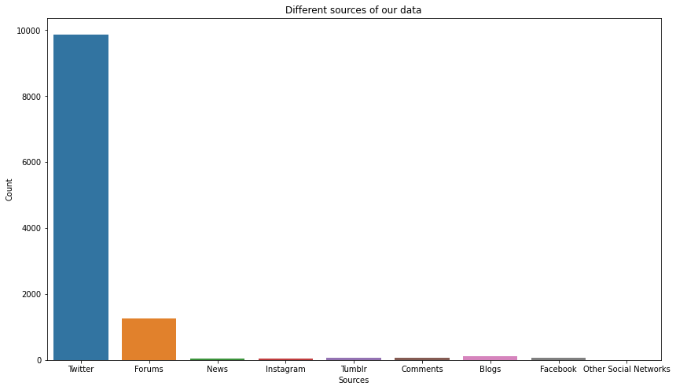

```python
# Plotting Different sources of our data
plot.hist_source()
```

- We notice, that the big part of our data goes to Twitter, that means that we've to work hard during preprocessing, because tweets, I guess, are complicated comparably to blogs or news.

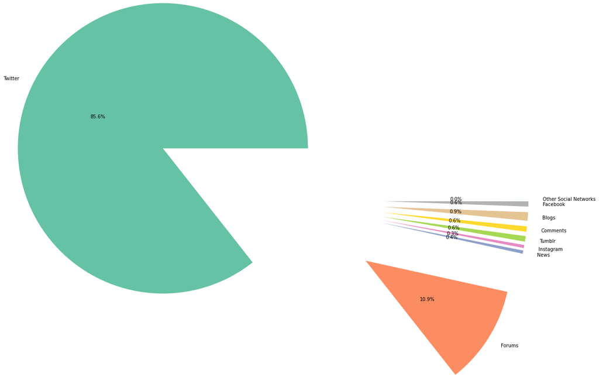

```python
# I plotted it like a pacman that eats dot :)
# to show you the dominated source
plot.pie_source()
```

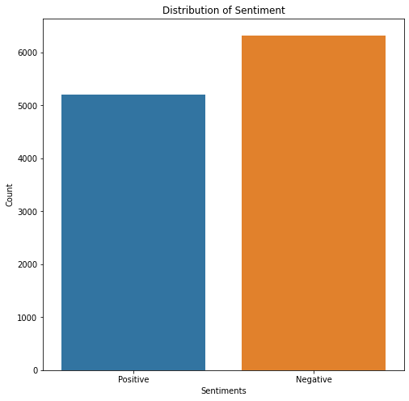

```python
# Plotting histogram of sentiments
plot.hist_target()
```

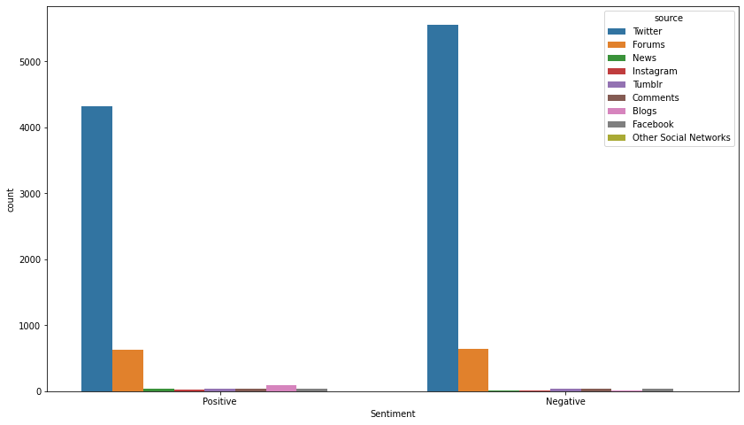

```python
# Plotting histogram of sentiments
plot.hist_target_source()
```

- Based on the last charts, We notice that we've balanced data, We're so lucky :)

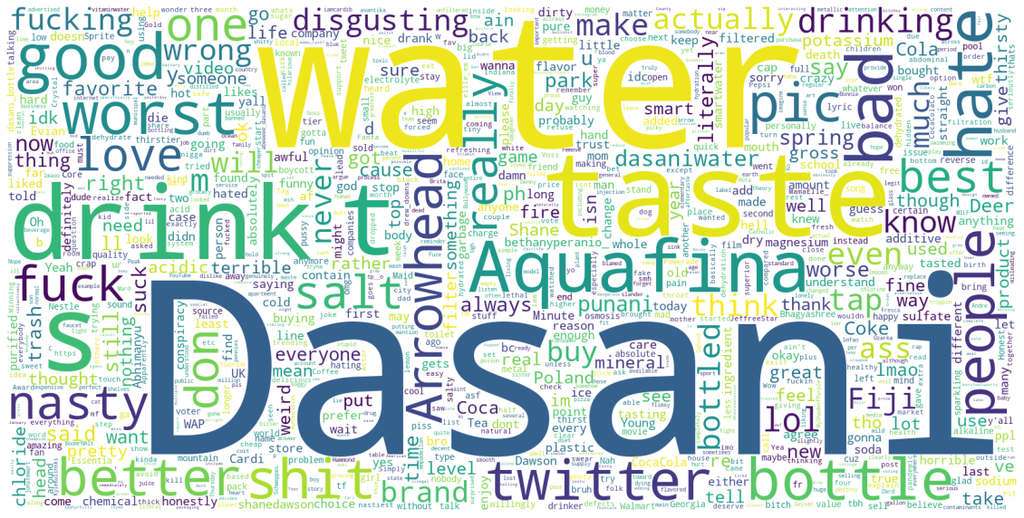

```python
# Plotting wordcloud
plot.plot_wordcloud()
```

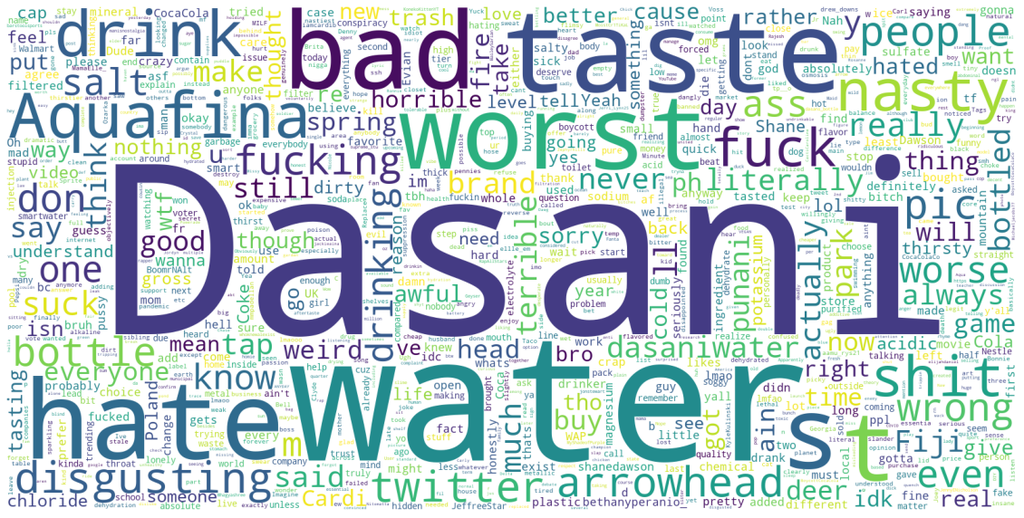

```python
# Plotting wordcloud of negative text
plot.plot_wordcloud('Negative')
```

## 2. Preprocessing & Building Models 🔼

### A. Machine Learning 🔼

In this section, we'll use ML Class (please find below diagram class of Data).

After instantiating class with the same path of preview section, We'll :

```
1. Remove stop words from our data
2. Clean text (removing punctuations, urls, tags ...)
3. Apply stemming
4. Split data
5. Apply TF-IDF vectorizer
6. Choose & fit the model (The class provide choosing one of the 3 models : SVM, BNB or Logistic Regression)
7. Predict & evaluate model
```

[figure not shown]

#### a. Architecture 🔼

This is the architecture of our ML approach.

For the step of applying TF-IDF vectorizer :

```
1. I Fitted the TF-IDF vectorizer on X_train
2. I used the same vectorizer to transform X_test & whole_X

/!\ whole_X is the final data that I'll project my models on it
```

[figure not shown]

```python
# Instantiate Viz class
ml = ML(PATH)

# I stored the whole data to return it back with its prediction in the last section
out = ml.get_whole_data().copy()
```

```python
# As I wrote, whole_X is the preprocessed whole data
# that I'll project my models on it in the last section
X_train, X_test, y_train, y_test, whole_X = ml.pre_process()
```

```
[!] Renaming columns for whole data ...
[!] Removing Stop Words ...
[!] Cleaning texts >> [ Removing punctuations, urls, tags ...] ...
[!] Applying Stemming ...
[!] Splitting data ...
[!] Applying TfidfVectorizer ...
```

#### b. Support Vector Machine 🔼

```
[!] Fitting the model ...
[!] Predicting values ...
[!] Evaluating the model ...
              precision    recall  f1-score   support

    Negative       0.94      0.89      0.91      1262
    Positive       0.88      0.93      0.90      1045

    accuracy                           0.91      2307
   macro avg       0.91      0.91      0.91      2307
weighted avg       0.91      0.91      0.91      2307
```

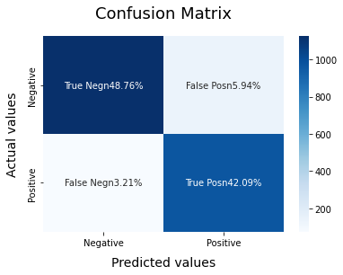

```python
# Choosing & fitting the SVM model
model_svm = ml.fit_model('SVM', X_train, y_train)

# Prediction & evaluating the model
y_pred = ml.predict_evaluate(model_svm, X_test, y_test)
```

#### c. Logistic Regression 🔼

```
[!] Fitting the model ...
[!] Predicting values ...
[!] Evaluating the model ...
              precision    recall  f1-score   support

    Negative       0.92      0.90      0.91      1262
    Positive       0.89      0.91      0.90      1045

    accuracy                           0.91      2307
   macro avg       0.90      0.91      0.91      2307
weighted avg       0.91      0.91      0.91      2307
```

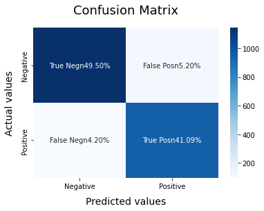

```python
# Choosing & fitting the SVM model
model_lr = ml.fit_model('LR', X_train, y_train)

# Prediction & evaluating the model
y_pred = ml.predict_evaluate(model_lr, X_test, y_test)
```

#### d. Bernoulli Naive Bayes 🔼

```
[!] Fitting the model ...
[!] Predicting values ...
[!] Evaluating the model ...
              precision    recall  f1-score   support

    Negative       0.63      0.97      0.76      1262
    Positive       0.89      0.30      0.45      1045

    accuracy                           0.67      2307
   macro avg       0.76      0.64      0.61      2307
weighted avg       0.75      0.67      0.62      2307
```

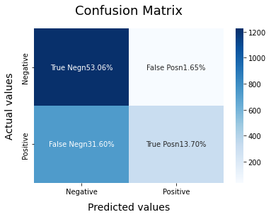

```python
# Choosing & fitting the SVM model
model_bnb = ml.fit_model('BNB', X_train, y_train)

# Prediction & evaluating the model
y_pred = ml.predict_evaluate(model_bnb, X_test, y_test)
```

### B. Deep Learning 🔼

In this section, we'll use DL & RNN Classes (please find below their diagrams ).

After instantiating class with the same path of preview section, We'll :

```
1. Defining hyperparameters
2. Cleaning text (removing punctuations, urls, tags ...)
4. Split data & save it to csv file (so that can be used by TabilaDataset later)
5. Build vocab just in X_train !
6. Read data as  TabularDataset
7. Creating iterators using BucketIterator
8. Build our model
9. Predict & evaluate the model
```

[figure not shown]

#### a. Architecture 🔼

This is the architecture of the whole process.

```
[!] I build vocab just in X_train to avoid reflecting the test & the fitting of the model.
```

[figure not shown]

#### b. Architecture of model 🔼

Now, I'm going to create my model using class RNN. This is the architecture :

[figure not shown]

The architecture contains 3 layers are :

```
[!] Embedding layer
[!] LSTM layer
[!] Linear layer

/!\ I initialised randomly parameters of each layer.
```

#### c. Preprocessing & Building model 🔼

```python
# Defining hyperparameters

RANDOM_SEED = 123
torch.manual_seed(RANDOM_SEED)

VOCABULARY_SIZE = 20000
LEARNING_RATE = 0.005
BATCH_SIZE = 128
NUM_EPOCHS = 15
DEVICE = torch.device('cuda:1' if torch.cuda.is_available() else 'cpu')

EMBEDDING_DIM = 128
HIDDEN_DIM = 256
```

```python
# Instantiate DL class
dl = DL(PATH)
```

```python
# Pre-processing data
train_data, test_data, val_data = dl.pre_processing()
```

```
[!] Cleaning data ...
[!] Splitting data ...
[!] Saving dataset ...
[!] Defining the feature processing ...
[!] Defining the sentiment processing ...
[!] Word -> id_word
	Vocabulary size: 8960
	Number of classes: 2
```

```python
print(vars(train_data.examples[0]))
```

```
{'TEXT_COLUMN_NAME': ['dasani', 'tastes', 'like', 'fucking', 'bleach', 'disgusting'], 'LABEL_COLUMN_NAME': 'Negative'}
```

```
[!] After building vocab, the target will be as follows :
    [!] Negative : 0
    [!] Positive : 1
```

```python
# Creating iterators using BucketIterator
train_loader, val_loader, test_loader = \
torchtext.legacy.data.BucketIterator.splits(
        (train_data, val_data, test_data),
         batch_size=BATCH_SIZE,
         sort_within_batch=False,
         sort_key=lambda x: len(x.TEXT_COLUMN_NAME),
         device=DEVICE
    )
```

```python
print('Train')
for batch in train_loader:
    print(f'Text matrix size: {batch.TEXT_COLUMN_NAME.size()}')
    print(f'Target vector size: {batch.LABEL_COLUMN_NAME.size()}')
    break

print('\nTest:')
for batch in test_loader:
    print(f'Text matrix size: {batch.TEXT_COLUMN_NAME.size()}')
    print(f'Target vector size: {batch.LABEL_COLUMN_NAME.size()}')
    break

print('\nVal:')
for batch in val_loader:
    print(f'Text matrix size: {batch.TEXT_COLUMN_NAME.size()}')
    print(f'Target vector size: {batch.LABEL_COLUMN_NAME.size()}')
    break
```

```
Train
Text matrix size: torch.Size([154, 128])
Target vector size: torch.Size([128])

Test:
Text matrix size: torch.Size([5, 128])
Target vector size: torch.Size([128])

Val:
Text matrix size: torch.Size([5, 128])
Target vector size: torch.Size([128])
```

```python
# Building model
torch.manual_seed(RANDOM_SEED)
model = RNN(input_dim= 8960, # 8960 is the Vocabulary size
            embedding_dim=EMBEDDING_DIM,
            hidden_dim=HIDDEN_DIM,
            output_dim=NUM_CLASSES
)

model = model.to(DEVICE)
optimizer = torch.optim.Adam(model.parameters(), lr=0.005)
```

```python
# I'll use this function to compute accuracy
# in next step
def compute_accuracy(model, data_loader, device):

    with torch.no_grad():

        correct_pred, num_examples = 0, 0

        for i, (features, targets) in enumerate(data_loader):

            features = features.to(device)
            targets = targets.float().to(device)

            logits = model(features)
            _, predicted_labels = torch.max(logits, 1)

            num_examples += targets.size(0)
            correct_pred += (predicted_labels == targets).sum()
    return correct_pred.float()/num_examples * 100
```

```python
start_time = time.time()

train_acc = []
val_acc = []
train_loss = []
val_loss = []

for epoch in range(NUM_EPOCHS):
    model.train()
    for batch_idx, batch_data in enumerate(train_loader):

        text = batch_data.TEXT_COLUMN_NAME.to(DEVICE)
        labels = batch_data.LABEL_COLUMN_NAME.to(DEVICE)

        ### FORWARD AND BACK PROP
        logits = model(text)
        loss = F.cross_entropy(logits, labels)
        optimizer.zero_grad()

        loss.backward()

        ### UPDATE MODEL PARAMETERS
        optimizer.step()

        ### LOGGING
        if not batch_idx % 50:
            print (f'Epoch: {epoch+1:03d}/{NUM_EPOCHS:03d} | '
                   f'Batch {batch_idx:03d}/{len(train_loader):03d} | '
                   f'Loss: {loss:.4f}')


    with torch.set_grad_enabled(False):
        print(f'training accuracy: '
              f'{compute_accuracy(model, train_loader, DEVICE):.2f}%'
              f'\nvalid accuracy: '
              f'{compute_accuracy(model, test_loader, DEVICE):.2f}%')
        train_acc.append(compute_accuracy(model, train_loader, DEVICE))
        val_acc.append(compute_accuracy(model, val_loader, DEVICE))

    print(f'Time elapsed: {(time.time() - start_time)/60:.2f} min')

print(f'Total Training Time: {(time.time() - start_time)/60:.2f} min')
print(f'Test accuracy: {compute_accuracy(model, test_loader, DEVICE):.2f}%')
```

```
Epoch: 001/015 | Batch 000/062 | Loss: 1.8156
Epoch: 001/015 | Batch 050/062 | Loss: 0.6829
training accuracy: 55.59%
valid accuracy: 42.46%
Time elapsed: 3.59 min
Epoch: 002/015 | Batch 000/062 | Loss: 0.6889
Epoch: 002/015 | Batch 050/062 | Loss: 0.6621
training accuracy: 77.01%
valid accuracy: 70.48%
Time elapsed: 6.27 min
Epoch: 003/015 | Batch 000/062 | Loss: 0.5187
Epoch: 003/015 | Batch 050/062 | Loss: 0.3288
training accuracy: 93.88%
valid accuracy: 89.37%
Time elapsed: 8.56 min
Epoch: 004/015 | Batch 000/062 | Loss: 0.2463
Epoch: 004/015 | Batch 050/062 | Loss: 0.1848
training accuracy: 97.53%
valid accuracy: 90.64%
Time elapsed: 10.93 min
Epoch: 005/015 | Batch 000/062 | Loss: 0.1291
Epoch: 005/015 | Batch 050/062 | Loss: 0.0582
training accuracy: 99.16%
valid accuracy: 91.22%
Time elapsed: 13.32 min
Epoch: 006/015 | Batch 000/062 | Loss: 0.0528
Epoch: 006/015 | Batch 050/062 | Loss: 0.0099
training accuracy: 99.54%
valid accuracy: 91.28%
Time elapsed: 15.89 min
Epoch: 007/015 | Batch 000/062 | Loss: 0.0191
Epoch: 007/015 | Batch 050/062 | Loss: 0.0024
training accuracy: 99.23%
valid accuracy: 91.05%
Time elapsed: 18.42 min
Epoch: 008/015 | Batch 000/062 | Loss: 0.0485
Epoch: 008/015 | Batch 050/062 | Loss: 0.0094
training accuracy: 99.67%
valid accuracy: 91.62%
Time elapsed: 20.97 min
```

[output cut: 22 more lines]

```
training accuracy: 99.89%
valid accuracy: 91.57%
Time elapsed: 34.20 min
Epoch: 014/015 | Batch 000/062 | Loss: 0.0009
Epoch: 014/015 | Batch 050/062 | Loss: 0.0109
training accuracy: 99.95%
valid accuracy: 91.62%
Time elapsed: 36.96 min
Epoch: 015/015 | Batch 000/062 | Loss: 0.0142
Epoch: 015/015 | Batch 050/062 | Loss: 0.0013
training accuracy: 99.72%
valid accuracy: 91.39%
Time elapsed: 39.71 min
Total Training Time: 39.71 min
Test accuracy: 91.39%
```

#### d. Results 🔼

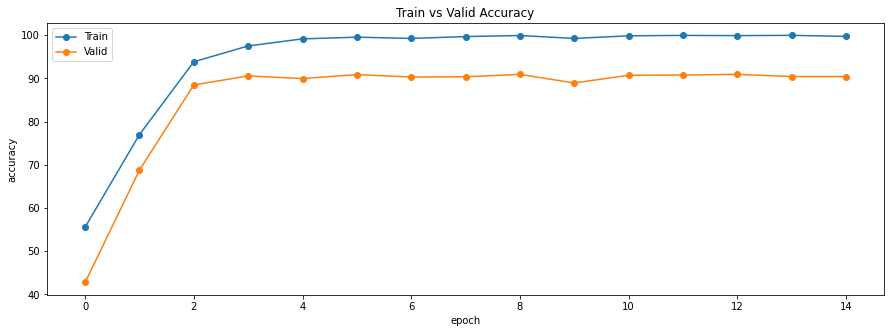

```python
import matplotlib.pyplot as plt

# ploting accuracy
plt.rcParams["figure.figsize"] = (15,5)

plt.plot(train_acc,'-o')
plt.plot(val_acc,'-o')
plt.xlabel('epoch')
plt.ylabel('accuracy')
plt.legend(['Train','Valid'])
plt.title('Train vs Valid Accuracy')

plt.savefig('valVStrain_acc.png')
plt.show()
```

[!] Apparently, an accuracy = 91.39% means that we got good results.

/!\ But there is a smell of overfitting! -> We can avoid it by adding some dropout to our model.

```python
# Saving the model !
torch.save(model, 'MODELS/rnn_model')
```

## 3. Testing Models on whole data 🔼

As I wrote, I already did the preprocessing of the whole data in this section.

This is the whole process :

```
[!] I renamed columns of the whole data
[!] I removed stop words (using nltk)
[!] I cleaned text (removing urls, tags ... )
[!] I applied stemming
[!] Then I got whole_X
[!] I applied the vectorizer that I fit it on X_train
[!] Now, It's time to pass data to the models
[!] For each model, I saved the predictions
```

[figure not shown]

```python
# Saving prediction in csv file
def predict_and_save(data, model, model_name, whole_X):

    if model_name == 'SVM' :
        path = 'OUTPUT/result_svm.csv'

    elif model_name == 'BNB' :
        path = 'OUTPUT/result_bnb.csv'

    elif model_name == 'LR' :
        path = 'OUTPUT/result_lr.csv'

    print(f'[!] Predicting sentiments... ')
    whole_Y = model.predict(whole_X)

    print(f'[!] Saving Predictions...')
    data['Sentiment'] = whole_Y

    data.to_csv(path, index = False)
    print(f'[!] Done ! Results was saved to {path} :)')
```

```python
predict_and_save(out, model_svm, 'SVM', whole_X)
```

```
[!] Predicting sentiments...
[!] Saving Predictions...
[!] Done ! Results was saved to OUTPUT/result_svm.csv :)
```

```python
predict_and_save(out, model_lr, 'LR', whole_X)
```

```
[!] Predicting sentiments...
[!] Saving Predictions...
[!] Done ! Results was saved to OUTPUT/result_lr.csv :)
```

```python
predict_and_save(out, model_bnb, 'BNB', whole_X)
```

```
[!] Predicting sentiments...
[!] Saving Predictions...
[!] Done ! Results was saved to OUTPUT/result_bnb.csv :)
```

```
[!] Examples :
```

```python
# Reading results
df_examples = pd.read_csv('OUTPUT/result_svm.csv')

# Example of positive sentence
print('[!] Case 1')
print(f'\tSentence => {df_examples.iloc[12,1]}\n \tPrediction => {df_examples.iloc[12,2]}')

print('[!] Case 2')
print(f'\tSentence => {df_examples.iloc[63,1]}\n \tPrediction => {df_examples.iloc[63,2]}')
```

```
[!] Case 1
	Sentence => Lmao everyone hates Dasani it's so funny. Give me whatever. As long as its room temperature & not thick im straight
 	Prediction => Positive
[!] Case 2
	Sentence =>  I hate dasani I hate it so much
 	Prediction => Negative
```

## 4. WHY ? 🔼

### A. These models 🔼

[!] We are dealing with a problem of sentiment's classification (positive or negative).

[!] To the best of my knowledge, i'd rather test SVM first because :

```
[!] It can be used in non-regularly distributed ( i.e. Data that has unknown distribution) -> after applying TF-IDF to
our data, we don't have any idea about the distribution that's why  !

[!] The outliers are less influence on the model -> In our case, sometimes some comments seem for TextBlob like
positive (it identified it like positive) but it's sarcastic. For example : "Lmao everyone hates Dasani it's so funny. Give me whatever. As long as its room temperature & not thick im straight"
```

[!] For Logistic Regression, I choose it because :

```
[!] It makes no assumptions about the distributions of classes in feature space. (Same as SVM)
[!] We can interpret the model after building it.
```

[!] For Bernoulli Naive Bayes, in order to confirm my hypothesis (during the interview) being aware that it is not the best option to consider (same as Gaussian Naive Bayes):

```
[!] In fact, their problem is that they assume that the features are supposed independent !
[!] In our case features are strongly dependent since we are working with sentences
```

[!] For LSTM, I implemented, but I usually use it when I have big texts as input to avoid the problem of Long Term dependencies.

### B. These metrics 🔼

[!] As stated previously, our data is balanced

```
[!] Accuracy is good representative metric of the model performance.
```

[!] But, during all projects I prefer also to use F1-score, It's more reliable than other metrics in most cases.

## 5. Conclusion & Perspectives 🔼

[output not shown]

[!] For LSTM, we can improve it by :

```
[!] Testing other architectures
[!] Regularization
[!] Performing dropout to avoid Overfitting
```

/!\ If there is some misclassed sentiment, it can be due to the annotation ! not to models